# Impact of Open Finance on Credit in Brazil

Analyzing Credit Growth, Default Rates, PIX Adoption, and the Role of Open Finance

Pranav Mehta

February 28, 2026

# 1 Objective

This notebook examines the **impact of Open Finance on credit in Brazil** by combining three data sources:

1. **SCR.Data** (Sistema de Informações de Crédito) — monthly aggregated credit data published by the Central Bank of Brazil (BCB), including active credit portfolios and default rates.
2. **PIX transaction volumes** — Brazil’s instant payment system, a core pillar of Open Finance infrastructure.
3. **Open Finance customer counts** — the number of customers with active data-sharing consents.

We investigate whether the expansion of Open Finance is associated with:

- **Credit growth** — larger active credit portfolios, controlling for macro conditions.
- **Lower default rates** — improved credit quality as information-sharing reduces adverse selection.
- **Differential effects by client type** — whether individuals (PF) and firms (PJ) are affected differently.

# 2 Background

## 2.1 Open Finance in Brazil

Brazil’s Open Finance initiative, regulated by the Central Bank, mandates that financial institutions share customer data (with consent) through standardized APIs. Launched in phases starting in 2021, the system aims to increase competition, reduce information asymmetries, and improve credit allocation. By enabling lenders to access a borrower’s full financial history across institutions, Open Finance has the potential to:

- **Expand credit access** — lenders can better assess previously opaque borrowers.
- **Reduce default rates** — richer information reduces adverse selection and improves risk pricing.
- **Lower interest rates** — increased competition among lenders benefits borrowers.

## 2.2 SCR (Sistema de Informações de Crédito)

The SCR is the Central Bank’s credit information system, containing loan-level data from all regulated financial institutions. The public **SCR.Data** release provides monthly aggregated statistics on:

- **Carteira Ativa** (Active Portfolio) — total outstanding credit stock, computed as the sum of amounts due (to mature and overdue) across credit modalities.
- **Inadimplência** (Default Rate) — the share of the portfolio with any installment overdue by more than 90 days.
- **Ativo Problemático** (Problem Assets) — broader measure of distressed credit.

Data is disaggregated by client type (PF: individuals, PJ: firms), credit modality, state, economic sector, and other dimensions.

## 2.3 PIX

PIX is Brazil’s instant payment system, launched in November 2020. It enables real-time, 24/7 transfers at zero cost to end users. In the Open Finance context, PIX enables payment initiation via third-party providers — a core infrastructure pillar.

## 2.4 Selic and IBC-Br

- **Selic**: Brazil’s policy interest rate target, the primary instrument for influencing inflation and economic activity.
- **IBC-Br**: The Central Bank’s monthly economic activity index, a high-frequency GDP proxy.

# 3 Data Sources

## 3.2 SCR.Data — Credit Variables

Monthly national aggregates from BCB’s SCR.Data portal, stored locally as CSV files:

- `carteira.csv` — Active credit portfolio (R$)
- `ativo-problemtico.csv` — Problem asset rate (%)
- `inadimplncia.csv` — Default rate (%)

Data covers June 2012 to June 2025 (national totals, all client types).

# 4 Load Existing Data (PIX, Customers, Macro)

```r
df_long <- read_excel("data/data_monthly.xlsx", sheet = 2) %>%
  mutate(month = dmy(paste0("01/", month)),
         month = ceiling_date(month, "month") - days(1))

df_short <- read_excel("data/data_monthly.xlsx", sheet = 1) %>%
  mutate(month = dmy(paste0("01/", month)),
         month = ceiling_date(month, "month") - days(1))

df_merged <- df_long %>%
  left_join(df_short %>% select(month, cust), by = "month")

cat("PIX/Macro series:", nrow(df_long), "months,",
    as.character(min(df_long$month)), "to", as.character(max(df_long$month)), "\n")
```

```
## PIX/Macro series: 62 months, 2020-11-30 to 2025-12-31
```

```r
cat("Months with customer data:", sum(!is.na(df_merged$cust)), "\n")
```

```
## Months with customer data: 36
```

# 5 Load SCR Credit Data from Local CSVs

The SCR credit data has been downloaded from BCB and is available as local CSV files covering June 2012 to June 2025.

## 5.1 National Totals

```r
# Read the three SCR CSV files (national totals)
# Files use UTF-8 with BOM, comma-separated, with YYYY-MM date format
df_carteira <- read_csv("data/carteira.csv", show_col_types = FALSE) %>%
  select(date = 1, credit_portfolio = 2)

df_ativo_prob <- read_csv("data/ativo-problemtico.csv", show_col_types = FALSE) %>%
  select(date = 1, problem_asset_rate = 2)

df_inadimplencia <- read_csv("data/inadimplncia.csv", show_col_types = FALSE) %>%
  select(date = 1, default_rate = 2)

# Merge the three series by date
scr_total <- df_carteira %>%
  left_join(df_ativo_prob, by = "date") %>%
  left_join(df_inadimplencia, by = "date") %>%
  mutate(
    month = ymd(paste0(date, "-01")),
    month = ceiling_date(month, "month") - days(1)
  ) %>%
  select(month, credit_portfolio, problem_asset_rate, default_rate)

cat("SCR credit data:", nrow(scr_total), "months\n")
```

```
## SCR credit data: 157 months
```

```r
cat("Date range:", as.character(min(scr_total$month)),
    "to", as.character(max(scr_total$month)), "\n")
```

```
## Date range: 2012-06-30 to 2025-06-30
```

```r
cat("Credit portfolio range: R$",
    format(min(scr_total$credit_portfolio), big.mark = ","),
    "to R$",
    format(max(scr_total$credit_portfolio), big.mark = ","), "\n")
```

```
## Credit portfolio range: R$ 2.111737e+12 to R$ 6.624747e+12
```

```r
cat("Default rate range:",
    round(min(scr_total$default_rate), 2), "% to",
    round(max(scr_total$default_rate), 2), "%\n")
```

```
## Default rate range: 2.01 % to 3.97 %
```

```r
summary(scr_total)
```

```
##      month            credit_portfolio    problem_asset_rate  default_rate
##  Min.   :2012-06-30   Min.   :2.112e+12   Min.   :5.490      Min.   :2.010
##  1st Qu.:2015-09-30   1st Qu.:3.024e+12   1st Qu.:6.120      1st Qu.:2.770
##  Median :2018-12-31   Median :3.184e+12   Median :7.040      Median :3.020
##  Mean   :2018-12-30   Mean   :3.796e+12   Mean   :6.928      Mean   :3.029
##  3rd Qu.:2022-03-31   3rd Qu.:4.740e+12   3rd Qu.:7.530      3rd Qu.:3.350
##  Max.   :2025-06-30   Max.   :6.625e+12   Max.   :8.470      Max.   :3.970
```

## 5.2 PF/PJ Breakdown

```r
# Read PF/PJ breakdown files
# Columns: Date, Brasil-Todas, Brasil-Todas (dup), Brasil-PF-Todas, Brasil-PJ-Todas
df_cart_pf_pj <- read_csv("data/carteira_pf_pj.csv", show_col_types = FALSE) %>%
  select(date = 1, credit_pf = 4, credit_pj = 5)

df_ativo_pf_pj <- read_csv("data/ativo_problematico_pf_pj.csv", show_col_types = FALSE) %>%
  select(date = 1, problem_rate_pf = 4, problem_rate_pj = 5)

df_inad_pf_pj <- read_csv("data/inadimplencia_pf_pj.csv", show_col_types = FALSE) %>%
  select(date = 1, default_rate_pf = 4, default_rate_pj = 5)

scr_pf_pj <- df_cart_pf_pj %>%
  left_join(df_ativo_pf_pj, by = "date") %>%
  left_join(df_inad_pf_pj, by = "date") %>%
  mutate(
    month = ymd(paste0(date, "-01")),
    month = ceiling_date(month, "month") - days(1)
  ) %>%
  select(month, credit_pf, credit_pj, problem_rate_pf, problem_rate_pj,
         default_rate_pf, default_rate_pj)

cat("PF/PJ data:", nrow(scr_pf_pj), "months\n")
```

```
## PF/PJ data: 157 months
```

```r
cat("PF credit range: R$", format(min(scr_pf_pj$credit_pf), big.mark = ","),
    "to R$", format(max(scr_pf_pj$credit_pf), big.mark = ","), "\n")
```

```
## PF credit range: R$ 957,469,781,513 to R$ 4.178212e+12
```

```r
cat("PJ credit range: R$", format(min(scr_pf_pj$credit_pj), big.mark = ","),
    "to R$", format(max(scr_pf_pj$credit_pj), big.mark = ","), "\n")
```

```
## PJ credit range: R$ 1.154267e+12 to R$ 2.446535e+12
```

## 5.3 PF Credit Modalities

```r
# Read PF modality breakdown (key sub-segments of individual credit)
# Columns: Date, Total, Total(dup), PF-Todas, PJ-Todas, then PF modalities:
#   Cartão de crédito, Consignação, Sem consignação, Habitacional,
#   Outros créditos, Rural, Veículos
df_cart_mod <- read_csv("data/carteira_pf_modalities.csv", show_col_types = FALSE) %>%
  select(date = 1,
         credit_pf_card = 6,
         credit_pf_payroll = 7,
         credit_pf_personal = 8,
         credit_pf_housing = 9,
         credit_pf_vehicles = 12)

scr_pf_mod <- df_cart_mod %>%
  mutate(
    month = ymd(paste0(date, "-01")),
    month = ceiling_date(month, "month") - days(1)
  ) %>%
  select(-date)

cat("PF modality data:", nrow(scr_pf_mod), "months\n")
```

```
## PF modality data: 157 months
```

```r
cat("Key PF credit modalities (latest month, R$ Bn):\n")
```

```
## Key PF credit modalities (latest month, R$ Bn):
```

```r
latest <- scr_pf_mod %>% filter(month == max(month))
cat("  Credit card:    ", round(latest$credit_pf_card / 1e9, 1), "\n")
```

```
##   Credit card:     633.9
```

```r
cat("  Payroll loans:  ", round(latest$credit_pf_payroll / 1e9, 1), "\n")
```

```
##   Payroll loans:   700.2
```

```r
cat("  Personal loans: ", round(latest$credit_pf_personal / 1e9, 1), "\n")
```

```
##   Personal loans:  344.6
```

```r
cat("  Housing:        ", round(latest$credit_pf_housing / 1e9, 1), "\n")
```

```
##   Housing:         1232.5
```

```r
cat("  Vehicles:       ", round(latest$credit_pf_vehicles / 1e9, 1), "\n")
```

```
##   Vehicles:        364.6
```

# 6 Merge All Data

```r
# Combine PIX/macro data with SCR credit data (total + PF/PJ + PF modalities)
df_all <- df_merged %>%
  left_join(scr_total, by = "month") %>%
  left_join(scr_pf_pj, by = "month") %>%
  left_join(scr_pf_mod, by = "month")

cat("Combined dataset:", nrow(df_all), "months\n")
```

```
## Combined dataset: 62 months
```

```r
cat("Months with credit data:", sum(!is.na(df_all$credit_portfolio)), "\n")
```

```
## Months with credit data: 56
```

```r
cat("Months with PF/PJ data:", sum(!is.na(df_all$credit_pf)), "\n")
```

```
## Months with PF/PJ data: 56
```

```r
cat("Months with customer + credit data:",
    sum(!is.na(df_all$cust) & !is.na(df_all$credit_portfolio)), "\n")
```

```
## Months with customer + credit data: 30
```

# 7 Feature Engineering

```r
safe_log <- function(x) ifelse(!is.na(x) & x > 0, log(x), NA_real_)

df_feat <- df_all %>%
  arrange(month) %>%
  mutate(
    ln_pix    = log(pix),
    ln_ibc_br = log(ibc_br),
    ln_cust   = safe_log(cust),
    ln_credit = safe_log(credit_portfolio),

    # PF/PJ logs
    ln_credit_pf = safe_log(credit_pf),
    ln_credit_pj = safe_log(credit_pj),

    # PF modality logs
    ln_pf_card     = safe_log(credit_pf_card),
    ln_pf_payroll  = safe_log(credit_pf_payroll),
    ln_pf_personal = safe_log(credit_pf_personal),
    ln_pf_housing  = safe_log(credit_pf_housing),

    # YoY growth rates (12-month log differences, %)
    g_yoy_ibc_br      = 100 * (ln_ibc_br - lag(ln_ibc_br, 12)),
    g_yoy_credit      = 100 * (ln_credit - lag(ln_credit, 12)),
    g_yoy_credit_pf   = 100 * (ln_credit_pf - lag(ln_credit_pf, 12)),
    g_yoy_credit_pj   = 100 * (ln_credit_pj - lag(ln_credit_pj, 12)),
    g_yoy_pf_card     = 100 * (ln_pf_card - lag(ln_pf_card, 12)),
    g_yoy_pf_payroll  = 100 * (ln_pf_payroll - lag(ln_pf_payroll, 12)),
    g_yoy_pf_personal = 100 * (ln_pf_personal - lag(ln_pf_personal, 12)),
    g_yoy_pf_housing  = 100 * (ln_pf_housing - lag(ln_pf_housing, 12)),

    # MoM growth rates
    g_mom_ibc_br = 100 * (ln_ibc_br - lag(ln_ibc_br, 1)),
    g_mom_credit = 100 * (ln_credit - lag(ln_credit, 1)),

    # Default rate YoY changes (pp)
    d_default_rate_yoy = default_rate - lag(default_rate, 12),
    d_default_pf_yoy   = default_rate_pf - lag(default_rate_pf, 12),
    d_default_pj_yoy   = default_rate_pj - lag(default_rate_pj, 12)
  )

cat("Observations with YoY credit growth:", sum(!is.na(df_feat$g_yoy_credit)), "\n")
```

```
## Observations with YoY credit growth: 44
```

```r
cat("Observations with YoY PF credit growth:", sum(!is.na(df_feat$g_yoy_credit_pf)), "\n")
```

```
## Observations with YoY PF credit growth: 44
```

```r
cat("Observations with customer data:", sum(!is.na(df_feat$ln_cust)), "\n")
```

```
## Observations with customer data: 36
```

# 8 Descriptive Analysis

## 8.1 Credit Portfolio Evolution

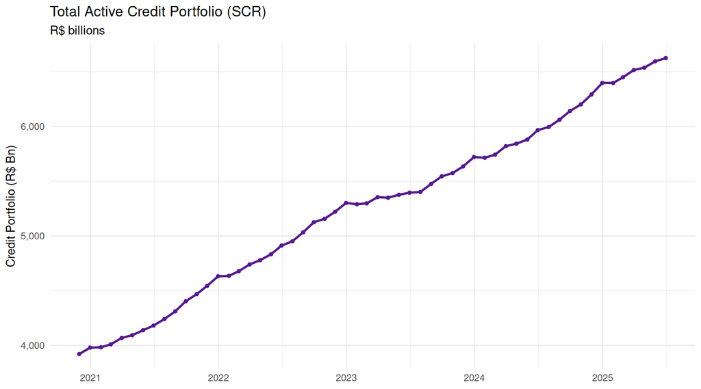

```r
df_feat %>%
  filter(!is.na(credit_portfolio)) %>%
  ggplot(aes(month, credit_portfolio / 1e9)) +
  geom_line(color = "purple4", linewidth = 1) +
  geom_point(color = "purple4", size = 1.2) +
  scale_y_continuous(labels = comma) +
  labs(title = "Total Active Credit Portfolio (SCR)",
       subtitle = "R$ billions",
       x = NULL, y = "Credit Portfolio (R$ Bn)") +
  theme_minimal()
```

## 8.2 Credit Portfolio by Client Type

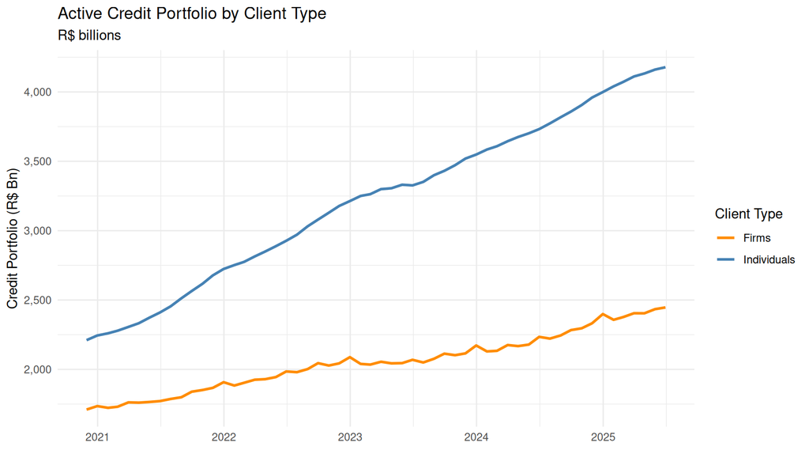

```r
df_feat %>%
  filter(!is.na(credit_pf)) %>%
  select(month, Individuals = credit_pf, Firms = credit_pj) %>%
  pivot_longer(-month, names_to = "Client Type", values_to = "portfolio") %>%
  ggplot(aes(month, portfolio / 1e9, color = `Client Type`)) +
  geom_line(linewidth = 1) +
  scale_y_continuous(labels = comma) +
  scale_color_manual(values = c("Individuals" = "steelblue", "Firms" = "darkorange")) +
  labs(title = "Active Credit Portfolio by Client Type",
       subtitle = "R$ billions",
       x = NULL, y = "Credit Portfolio (R$ Bn)") +
  theme_minimal()
```

## 8.3 PF Credit by Modality

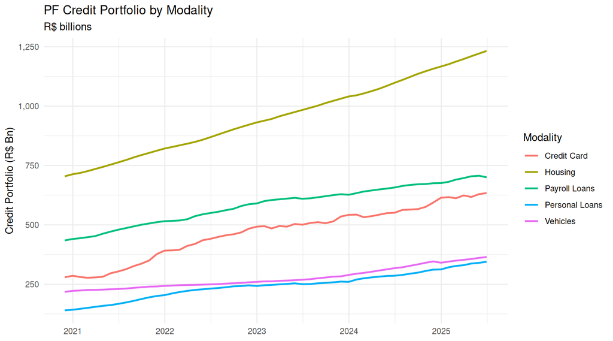

```r
df_feat %>%
  filter(!is.na(credit_pf_card)) %>%
  select(month,
         `Credit Card` = credit_pf_card,
         `Payroll Loans` = credit_pf_payroll,
         `Personal Loans` = credit_pf_personal,
         Housing = credit_pf_housing,
         Vehicles = credit_pf_vehicles) %>%
  pivot_longer(-month, names_to = "Modality", values_to = "portfolio") %>%
  ggplot(aes(month, portfolio / 1e9, color = Modality)) +
  geom_line(linewidth = 0.9) +
  scale_y_continuous(labels = comma) +
  labs(title = "PF Credit Portfolio by Modality",
       subtitle = "R$ billions",
       x = NULL, y = "Credit Portfolio (R$ Bn)") +
  theme_minimal()
```

## 8.4 Default Rates

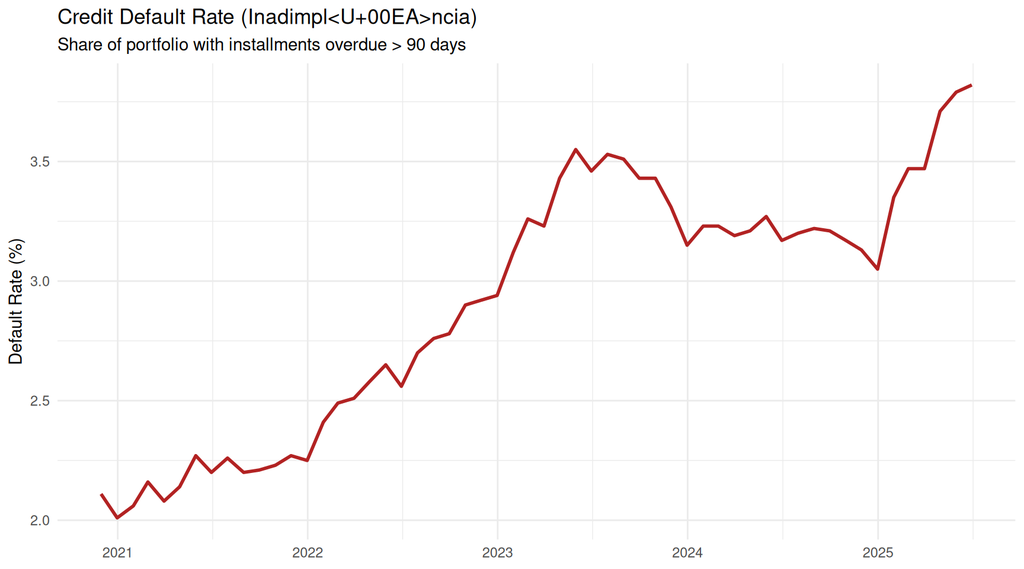

```r
df_feat %>%
  filter(!is.na(default_rate)) %>%
  ggplot(aes(month, default_rate)) +
  geom_line(color = "firebrick", linewidth = 1) +
  labs(title = "Credit Default Rate (Inadimplência)",
       subtitle = "Share of portfolio with installments overdue > 90 days",
       x = NULL, y = "Default Rate (%)") +
  theme_minimal()
```

## 8.5 Default Rate by Client Type

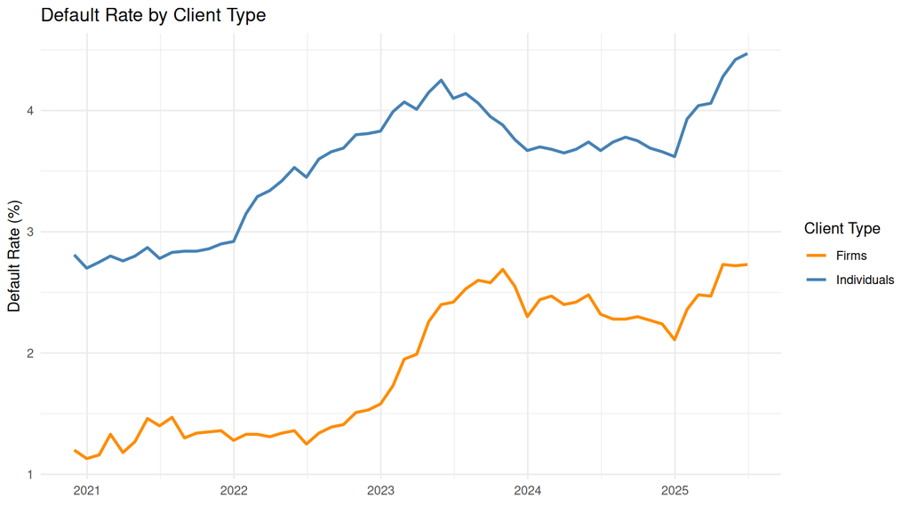

```r
df_feat %>%
  filter(!is.na(default_rate_pf)) %>%
  select(month, Individuals = default_rate_pf, Firms = default_rate_pj) %>%
  pivot_longer(-month, names_to = "Client Type", values_to = "rate") %>%
  ggplot(aes(month, rate, color = `Client Type`)) +
  geom_line(linewidth = 1) +
  scale_color_manual(values = c("Individuals" = "steelblue", "Firms" = "darkorange")) +
  labs(title = "Default Rate by Client Type",
       x = NULL, y = "Default Rate (%)") +
  theme_minimal()
```

## 8.6 Credit YoY Growth

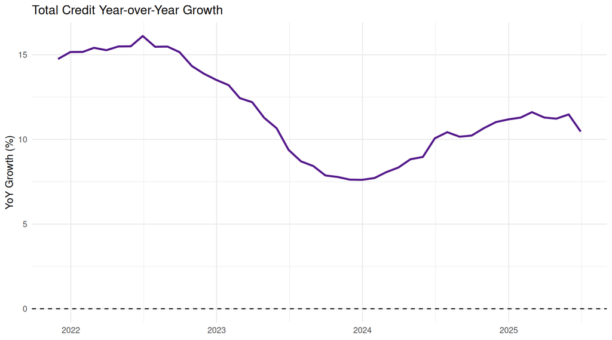

```r
df_feat %>%
  filter(!is.na(g_yoy_credit)) %>%
  ggplot(aes(month, g_yoy_credit)) +
  geom_line(color = "purple4", linewidth = 1) +
  geom_hline(yintercept = 0, linetype = "dashed") +
  labs(title = "Total Credit Year-over-Year Growth",
       x = NULL, y = "YoY Growth (%)") +
  theme_minimal()
```

## 8.7 PIX Transaction Volumes

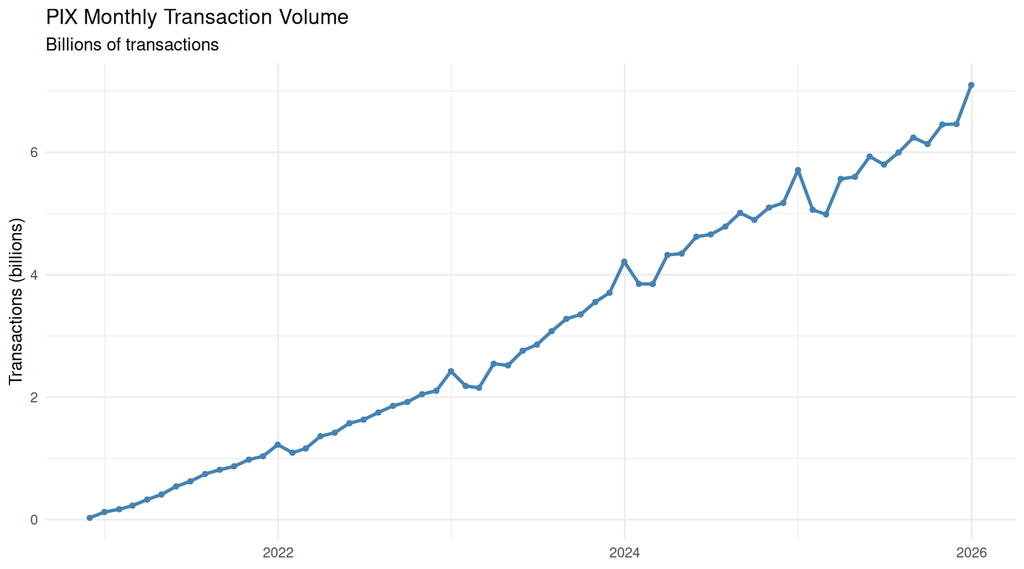

```r
df_feat %>%
  ggplot(aes(month, pix / 1e9)) +
  geom_line(color = "steelblue", linewidth = 1) +
  geom_point(color = "steelblue", size = 1.2) +
  scale_y_continuous(labels = comma) +
  labs(title = "PIX Monthly Transaction Volume",
       subtitle = "Billions of transactions",
       x = NULL, y = "Transactions (billions)") +
  theme_minimal()
```

## 8.8 Open Finance Customer Counts

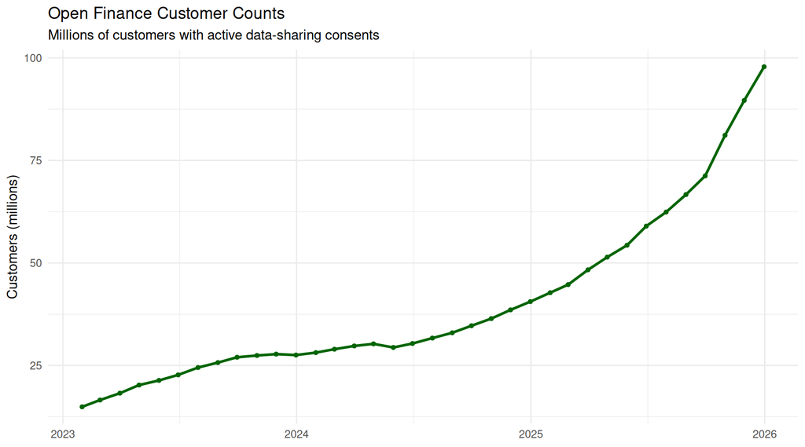

```r
df_feat %>%
  filter(!is.na(cust)) %>%
  ggplot(aes(month, cust / 1e6)) +
  geom_line(color = "darkgreen", linewidth = 1) +
  geom_point(color = "darkgreen", size = 1.2) +
  scale_y_continuous(labels = comma) +
  labs(title = "Open Finance Customer Counts",
       subtitle = "Millions of customers with active data-sharing consents",
       x = NULL, y = "Customers (millions)") +
  theme_minimal()
```

## 8.9 Combined Dashboard

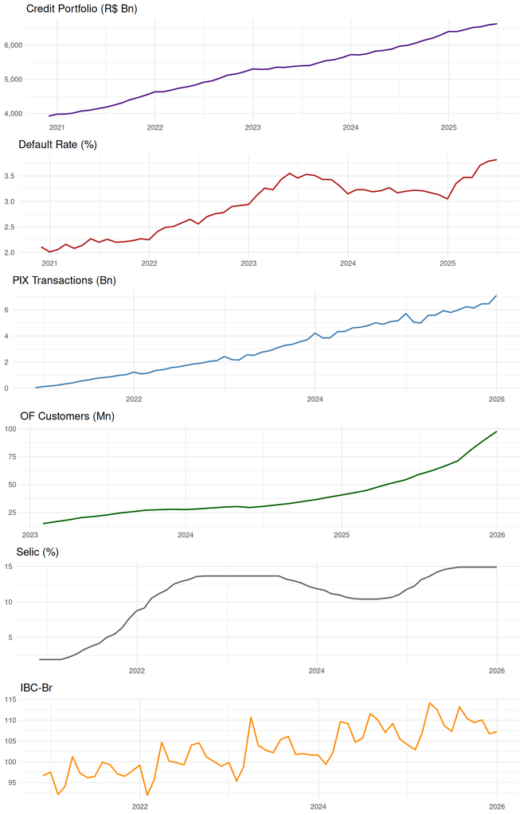

```r
p1 <- df_feat %>%
  filter(!is.na(credit_portfolio)) %>%
  ggplot(aes(month, credit_portfolio / 1e9)) +
  geom_line(color = "purple4", linewidth = 0.8) +
  scale_y_continuous(labels = comma) +
  labs(title = "Credit Portfolio (R$ Bn)", x = NULL, y = NULL) +
  theme_minimal()

p2 <- df_feat %>%
  filter(!is.na(default_rate)) %>%
  ggplot(aes(month, default_rate)) +
  geom_line(color = "firebrick", linewidth = 0.8) +
  labs(title = "Default Rate (%)", x = NULL, y = NULL) +
  theme_minimal()

p3 <- df_feat %>%
  ggplot(aes(month, pix / 1e9)) +
  geom_line(color = "steelblue", linewidth = 0.8) +
  scale_y_continuous(labels = comma) +
  labs(title = "PIX Transactions (Bn)", x = NULL, y = NULL) +
  theme_minimal()

p4 <- df_feat %>%
  filter(!is.na(cust)) %>%
  ggplot(aes(month, cust / 1e6)) +
  geom_line(color = "darkgreen", linewidth = 0.8) +
  scale_y_continuous(labels = comma) +
  labs(title = "OF Customers (Mn)", x = NULL, y = NULL) +
  theme_minimal()

p5 <- df_feat %>%
  ggplot(aes(month, selic)) +
  geom_line(color = "grey40", linewidth = 0.8) +
  labs(title = "Selic (%)", x = NULL, y = NULL) +
  theme_minimal()

p6 <- df_feat %>%
  ggplot(aes(month, ibc_br)) +
  geom_line(color = "darkorange", linewidth = 0.8) +
  labs(title = "IBC-Br", x = NULL, y = NULL) +
  theme_minimal()

gridExtra::grid.arrange(p1, p2, p3, p4, p5, p6, ncol = 1)
```

## 8.10 Correlation Matrix

```r
cor_vars <- df_feat %>%
  select(credit_portfolio, default_rate, pix, cust, selic, ibc_br) %>%
  drop_na()

cat("Correlation matrix (months with all variables, N =", nrow(cor_vars), "):\n\n")
```

```
## Correlation matrix (months with all variables, N = 30 ):
```

```r
round(cor(cor_vars), 3)
```

```
##                  credit_portfolio default_rate    pix  cust  selic ibc_br
## credit_portfolio            1.000        0.233  0.966 0.959 -0.099  0.560
## default_rate                0.233        1.000  0.136 0.474  0.751  0.225
## pix                         0.966        0.136  1.000 0.912 -0.271  0.590
## cust                        0.959        0.474  0.912 1.000  0.114  0.544
## selic                      -0.099        0.751 -0.271 0.114  1.000 -0.116
## ibc_br                      0.560        0.225  0.590 0.544 -0.116  1.000
```

# 9 Regression Framework

We estimate time-series OLS regressions with **Newey–West (HAC) standard errors** to address autocorrelation and heteroskedasticity. The analysis covers credit growth and default rates at the national level, by client type (PF/PJ), and for key PF credit modalities.

## 9.1 Part A — Credit Growth Models

Tests whether Open Finance adoption is associated with **credit expansion**, controlling for macro conditions:

$$g^{yoy}_{Credit,t}
=
\beta_0
+
\beta_1 \, Selic_t
+
\beta_2 \, g^{yoy}_{IBC\text{-}Br,t}
+
\beta_3 \, \ln(\text{Customers}_t)
+
\varepsilon_t$$

- $\beta_3 > 0$: Open Finance adoption is associated with faster credit growth.

## 9.2 Part B — Default Rate Models

Tests whether Open Finance adoption is associated with **improved credit quality**:

$$\Delta_{12} \, Default_t
=
\beta_0
+
\beta_1 \, Selic_t
+
\beta_2 \, g^{yoy}_{IBC\text{-}Br,t}
+
\beta_3 \, \ln(\text{Customers}_t)
+
\varepsilon_t$$

- $\beta_3 < 0$: Open Finance adoption is associated with declining default rates (better credit quality).

# 10 Part A: Credit Growth Models

## 10.1 Baseline: Credit Growth ~ Selic + IBC-Br Growth

```r
df_m_cred <- df_feat %>%
  select(month, g_yoy_credit, selic, g_yoy_ibc_br) %>%
  drop_na()

nw_lag <- function(n) max(1, floor(0.75 * n^(1/3)))

m_cred_base <- lm(g_yoy_credit ~ selic + g_yoy_ibc_br, data = df_m_cred)
nw_cred_base <- NeweyWest(m_cred_base, lag = nw_lag(nrow(df_m_cred)), prewhite = FALSE)

cat("Credit baseline: N =", nrow(df_m_cred), ", R² =", round(summary(m_cred_base)$r.squared, 4), "\n")
```

```
## Credit baseline: N = 44 , R² = 0.0048
```

```r
coeftest(m_cred_base, vcov = nw_cred_base)
```

```
##
## t test of coefficients:
##
##               Estimate Std. Error t value Pr(>|t|)
## (Intercept)  12.058792   5.083588  2.3721  0.02246 *
## selic        -0.062706   0.376731 -0.1664  0.86862
## g_yoy_ibc_br  0.105865   0.297546  0.3558  0.72382
## ---
## Signif. codes:  0 '***' 0.001 '**' 0.01 '*' 0.05 '.' 0.1 ' ' 1
```

## 10.2 Extended: Credit Growth ~ Selic + IBC-Br + ln(Customers)

```r
df_m_cred_ext <- df_feat %>%
  select(month, g_yoy_credit, selic, g_yoy_ibc_br, ln_cust) %>%
  drop_na()

m_cred_ext <- lm(g_yoy_credit ~ selic + g_yoy_ibc_br + ln_cust, data = df_m_cred_ext)
nw_cred_ext <- NeweyWest(m_cred_ext, lag = nw_lag(nrow(df_m_cred_ext)), prewhite = FALSE)

cat("Credit + OF: N =", nrow(df_m_cred_ext), ", R² =", round(summary(m_cred_ext)$r.squared, 4), "\n")
```

```
## Credit + OF: N = 30 , R² = 0.4298
```

```r
coeftest(m_cred_ext, vcov = nw_cred_ext)
```

```
##
## t test of coefficients:
##
##              Estimate Std. Error t value  Pr(>|t|)
## (Intercept)  -0.77897   14.38713 -0.0541 0.9572345
## selic         0.52907    0.13887  3.8099 0.0007661 ***
## g_yoy_ibc_br  0.56508    0.16133  3.5025 0.0016854 **
## ln_cust       0.14140    0.89272  0.1584 0.8753744
## ---
## Signif. codes:  0 '***' 0.001 '**' 0.01 '*' 0.05 '.' 0.1 ' ' 1
```

## 10.3 Credit Growth by Client Type

```r
# PF (Individuals)
df_m_pf <- df_feat %>%
  select(month, g_yoy_credit_pf, selic, g_yoy_ibc_br, ln_cust) %>% drop_na()

m_pf <- lm(g_yoy_credit_pf ~ selic + g_yoy_ibc_br + ln_cust, data = df_m_pf)
nw_pf <- NeweyWest(m_pf, lag = nw_lag(nrow(df_m_pf)), prewhite = FALSE)

cat("Credit PF + OF: N =", nrow(df_m_pf), ", R² =", round(summary(m_pf)$r.squared, 4), "\n")
```

```
## Credit PF + OF: N = 30 , R² = 0.6896
```

```r
coeftest(m_pf, vcov = nw_pf)
```

```
##
## t test of coefficients:
##
##              Estimate Std. Error t value  Pr(>|t|)
## (Intercept)  51.87395   10.76072  4.8207 5.395e-05 ***
## selic         0.70788    0.11826  5.9861 2.552e-06 ***
## g_yoy_ibc_br  0.50882    0.12195  4.1722 0.0002980 ***
## ln_cust      -2.91735    0.66704 -4.3736 0.0001755 ***
## ---
## Signif. codes:  0 '***' 0.001 '**' 0.01 '*' 0.05 '.' 0.1 ' ' 1
```

```r
# PJ (Firms)
df_m_pj <- df_feat %>%
  select(month, g_yoy_credit_pj, selic, g_yoy_ibc_br, ln_cust) %>% drop_na()

m_pj <- lm(g_yoy_credit_pj ~ selic + g_yoy_ibc_br + ln_cust, data = df_m_pj)
nw_pj <- NeweyWest(m_pj, lag = nw_lag(nrow(df_m_pj)), prewhite = FALSE)

cat("\nCredit PJ + OF: N =", nrow(df_m_pj), ", R² =", round(summary(m_pj)$r.squared, 4), "\n")
```

```
##
## Credit PJ + OF: N = 30 , R² = 0.5973
```

```r
coeftest(m_pj, vcov = nw_pj)
```

```
##
## t test of coefficients:
##
##               Estimate Std. Error t value  Pr(>|t|)
## (Intercept)  -80.99542   20.87185 -3.8806 0.0006378 ***
## selic          0.29295    0.18815  1.5571 0.1315455
## g_yoy_ibc_br   0.65950    0.22920  2.8775 0.0079076 **
## ln_cust        4.76567    1.29244  3.6874 0.0010508 **
## ---
## Signif. codes:  0 '***' 0.001 '**' 0.01 '*' 0.05 '.' 0.1 ' ' 1
```

## 10.4 PF Credit Growth by Modality

```r
# Credit card
df_m_card <- df_feat %>%
  select(month, g_yoy_pf_card, selic, g_yoy_ibc_br, ln_cust) %>% drop_na()

m_card <- lm(g_yoy_pf_card ~ selic + g_yoy_ibc_br + ln_cust, data = df_m_card)
nw_card <- NeweyWest(m_card, lag = nw_lag(nrow(df_m_card)), prewhite = FALSE)

cat("PF Card + OF: N =", nrow(df_m_card), ", R² =", round(summary(m_card)$r.squared, 4), "\n")
```

```
## PF Card + OF: N = 30 , R² = 0.7068
```

```r
coeftest(m_card, vcov = nw_card)
```

```
##
## t test of coefficients:
##
##              Estimate Std. Error t value  Pr(>|t|)
## (Intercept)  52.91159   28.08692  1.8839 0.0708149 .
## selic         1.78774    0.23004  7.7714 3.033e-08 ***
## g_yoy_ibc_br  0.90655    0.22788  3.9781 0.0004949 ***
## ln_cust      -3.80533    1.75256 -2.1713 0.0392205 *
## ---
## Signif. codes:  0 '***' 0.001 '**' 0.01 '*' 0.05 '.' 0.1 ' ' 1
```

```r
# Personal loans (sem consignação — highest information friction)
df_m_pers <- df_feat %>%
  select(month, g_yoy_pf_personal, selic, g_yoy_ibc_br, ln_cust) %>% drop_na()

m_pers <- lm(g_yoy_pf_personal ~ selic + g_yoy_ibc_br + ln_cust, data = df_m_pers)
nw_pers <- NeweyWest(m_pers, lag = nw_lag(nrow(df_m_pers)), prewhite = FALSE)

cat("\nPF Personal + OF: N =", nrow(df_m_pers), ", R² =", round(summary(m_pers)$r.squared, 4), "\n")
```

```
##
## PF Personal + OF: N = 30 , R² = 0.5584
```

```r
coeftest(m_pers, vcov = nw_pers)
```

```
##
## t test of coefficients:
##
##                Estimate Std. Error t value Pr(>|t|)
## (Intercept)  -126.66162   37.08721 -3.4152 0.002102 **
## selic           0.32925    0.32386  1.0167 0.318684
## g_yoy_ibc_br    1.10914    0.40951  2.7085 0.011795 *
## ln_cust         7.64089    2.30044  3.3215 0.002661 **
## ---
## Signif. codes:  0 '***' 0.001 '**' 0.01 '*' 0.05 '.' 0.1 ' ' 1
```

```r
# Housing
df_m_house <- df_feat %>%
  select(month, g_yoy_pf_housing, selic, g_yoy_ibc_br, ln_cust) %>% drop_na()

m_house <- lm(g_yoy_pf_housing ~ selic + g_yoy_ibc_br + ln_cust, data = df_m_house)
nw_house <- NeweyWest(m_house, lag = nw_lag(nrow(df_m_house)), prewhite = FALSE)

cat("\nPF Housing + OF: N =", nrow(df_m_house), ", R² =", round(summary(m_house)$r.squared, 4), "\n")
```

```
##
## PF Housing + OF: N = 30 , R² = 0.7657
```

```r
coeftest(m_house, vcov = nw_house)
```

```
##
## t test of coefficients:
##
##               Estimate Std. Error t value  Pr(>|t|)
## (Intercept)  17.886340   3.066577  5.8327 3.795e-06 ***
## selic         0.371029   0.048753  7.6104 4.453e-08 ***
## g_yoy_ibc_br  0.151735   0.020121  7.5411 5.258e-08 ***
## ln_cust      -0.657471   0.176634 -3.7222 0.0009606 ***
## ---
## Signif. codes:  0 '***' 0.001 '**' 0.01 '*' 0.05 '.' 0.1 ' ' 1
```

# 11 Part B: Default Rate Models

## 11.1 Baseline: Default Rate Change ~ Selic + IBC-Br Growth

```r
df_m_def <- df_feat %>%
  select(month, d_default_rate_yoy, selic, g_yoy_ibc_br) %>%
  drop_na()

m_def_base <- lm(d_default_rate_yoy ~ selic + g_yoy_ibc_br, data = df_m_def)
nw_def_base <- NeweyWest(m_def_base, lag = nw_lag(nrow(df_m_def)), prewhite = FALSE)

cat("Default baseline: N =", nrow(df_m_def), ", R² =", round(summary(m_def_base)$r.squared, 4), "\n")
```

```
## Default baseline: N = 44 , R² = 0.6208
```

```r
coeftest(m_def_base, vcov = nw_def_base)
```

```
##
## t test of coefficients:
##
##               Estimate Std. Error t value  Pr(>|t|)
## (Intercept)  -1.508946   0.547212 -2.7575 0.0086579 **
## selic         0.169803   0.039467  4.3024 0.0001021 ***
## g_yoy_ibc_br -0.076166   0.025699 -2.9638 0.0050427 **
## ---
## Signif. codes:  0 '***' 0.001 '**' 0.01 '*' 0.05 '.' 0.1 ' ' 1
```

## 11.2 Extended: Default Rate Change ~ Selic + IBC-Br + ln(Customers)

```r
df_m_def_ext <- df_feat %>%
  select(month, d_default_rate_yoy, selic, g_yoy_ibc_br, ln_cust) %>%
  drop_na()

m_def_ext <- lm(d_default_rate_yoy ~ selic + g_yoy_ibc_br + ln_cust, data = df_m_def_ext)
nw_def_ext <- NeweyWest(m_def_ext, lag = nw_lag(nrow(df_m_def_ext)), prewhite = FALSE)

cat("Default + OF: N =", nrow(df_m_def_ext), ", R² =", round(summary(m_def_ext)$r.squared, 4), "\n")
```

```
## Default + OF: N = 30 , R² = 0.9594
```

```r
coeftest(m_def_ext, vcov = nw_def_ext)
```

```
##
## t test of coefficients:
##
##               Estimate Std. Error t value  Pr(>|t|)
## (Intercept)   4.849868   1.248198  3.8855 0.0006298 ***
## selic         0.263118   0.013907 18.9200 < 2.2e-16 ***
## g_yoy_ibc_br -0.027543   0.012374 -2.2259 0.0349028 *
## ln_cust      -0.448864   0.076905 -5.8366 3.756e-06 ***
## ---
## Signif. codes:  0 '***' 0.001 '**' 0.01 '*' 0.05 '.' 0.1 ' ' 1
```

## 11.3 Default Rate by Client Type

```r
# PF
df_m_def_pf <- df_feat %>%
  select(month, d_default_pf_yoy, selic, g_yoy_ibc_br, ln_cust) %>% drop_na()

m_def_pf <- lm(d_default_pf_yoy ~ selic + g_yoy_ibc_br + ln_cust, data = df_m_def_pf)
nw_def_pf <- NeweyWest(m_def_pf, lag = nw_lag(nrow(df_m_def_pf)), prewhite = FALSE)

cat("Default PF + OF: N =", nrow(df_m_def_pf), ", R² =", round(summary(m_def_pf)$r.squared, 4), "\n")
```

```
## Default PF + OF: N = 30 , R² = 0.9348
```

```r
coeftest(m_def_pf, vcov = nw_def_pf)
```

```
##
## t test of coefficients:
##
##               Estimate Std. Error t value  Pr(>|t|)
## (Intercept)  -0.645386   0.930508 -0.6936  0.494094
## selic         0.313735   0.015757 19.9113 < 2.2e-16 ***
## g_yoy_ibc_br  0.037091   0.010650  3.4826  0.001773 **
## ln_cust      -0.185093   0.055278 -3.3484  0.002488 **
## ---
## Signif. codes:  0 '***' 0.001 '**' 0.01 '*' 0.05 '.' 0.1 ' ' 1
```

```r
# PJ
df_m_def_pj <- df_feat %>%
  select(month, d_default_pj_yoy, selic, g_yoy_ibc_br, ln_cust) %>% drop_na()

m_def_pj <- lm(d_default_pj_yoy ~ selic + g_yoy_ibc_br + ln_cust, data = df_m_def_pj)
nw_def_pj <- NeweyWest(m_def_pj, lag = nw_lag(nrow(df_m_def_pj)), prewhite = FALSE)

cat("\nDefault PJ + OF: N =", nrow(df_m_def_pj), ", R² =", round(summary(m_def_pj)$r.squared, 4), "\n")
```

```
##
## Default PJ + OF: N = 30 , R² = 0.7082
```

```r
coeftest(m_def_pj, vcov = nw_def_pj)
```

```
##
## t test of coefficients:
##
##               Estimate Std. Error t value Pr(>|t|)
## (Intercept)  11.914766   3.841474  3.1016 0.004592 **
## selic         0.169073   0.034501  4.9005 4.37e-05 ***
## g_yoy_ibc_br -0.129455   0.037934 -3.4127 0.002116 **
## ln_cust      -0.764909   0.238709 -3.2044 0.003564 **
## ---
## Signif. codes:  0 '***' 0.001 '**' 0.01 '*' 0.05 '.' 0.1 ' ' 1
```

# 12 Alternative Specification: Month-over-Month Growth

For robustness, we also estimate credit models using MoM growth rates.

```r
df_mom_cred <- df_feat %>%
  select(month, g_mom_credit, selic, g_mom_ibc_br) %>% drop_na()

m_mom_cred <- lm(g_mom_credit ~ selic + g_mom_ibc_br, data = df_mom_cred)
nw_mom_cred <- NeweyWest(m_mom_cred, lag = nw_lag(nrow(df_mom_cred)), prewhite = FALSE)

cat("Credit MoM baseline: N =", nrow(df_mom_cred), ", R² =", round(summary(m_mom_cred)$r.squared, 4), "\n")
```

```
## Credit MoM baseline: N = 55 , R² = 0.1015
```

```r
coeftest(m_mom_cred, vcov = nw_mom_cred)
```

```
##
## t test of coefficients:
##
##               Estimate Std. Error t value  Pr(>|t|)
## (Intercept)   1.298941   0.269315  4.8231 1.275e-05 ***
## selic        -0.033699   0.023550 -1.4309   0.15844
## g_mom_ibc_br  0.035399   0.015496  2.2844   0.02646 *
## ---
## Signif. codes:  0 '***' 0.001 '**' 0.01 '*' 0.05 '.' 0.1 ' ' 1
```

```r
df_mom_cred_ext <- df_feat %>%
  select(month, g_mom_credit, selic, g_mom_ibc_br, ln_cust) %>% drop_na()

m_mom_cred_ext <- lm(g_mom_credit ~ selic + g_mom_ibc_br + ln_cust, data = df_mom_cred_ext)
nw_mom_cred_ext <- NeweyWest(m_mom_cred_ext, lag = nw_lag(nrow(df_mom_cred_ext)), prewhite = FALSE)

cat("\nCredit MoM + OF: N =", nrow(df_mom_cred_ext), ", R² =", round(summary(m_mom_cred_ext)$r.squared, 4), "\n")
```

```
##
## Credit MoM + OF: N = 30 , R² = 0.2386
```

```r
coeftest(m_mom_cred_ext, vcov = nw_mom_cred_ext)
```

```
##
## t test of coefficients:
##
##               Estimate Std. Error t value  Pr(>|t|)
## (Intercept)  -5.266751   2.459874 -2.1411 0.0418138 *
## selic        -0.133623   0.035352 -3.7798 0.0008281 ***
## g_mom_ibc_br  0.027897   0.020508  1.3603 0.1854137
## ln_cust       0.444209   0.144949  3.0646 0.0050283 **
## ---
## Signif. codes:  0 '***' 0.001 '**' 0.01 '*' 0.05 '.' 0.1 ' ' 1
```

# 13 Summary of Results

```r
extract_results <- function(model, nw_vcov, label) {
  ct <- coeftest(model, vcov = nw_vcov)
  tibble(
    Model = label,
    Term = rownames(ct),
    Estimate = ct[, "Estimate"],
    `SE (HAC)` = ct[, "Std. Error"],
    `t` = ct[, "t value"],
    `p` = ct[, "Pr(>|t|)"],
    R2 = summary(model)$r.squared,
    N = nobs(model)
  )
}

models <- list(
  "Credit Base (YoY)"  = list(m_cred_base, nw_cred_base),
  "Credit + OF (YoY)"  = list(m_cred_ext, nw_cred_ext),
  "Credit PF + OF"     = list(m_pf, nw_pf),
  "Credit PJ + OF"     = list(m_pj, nw_pj),
  "PF Card + OF"       = list(m_card, nw_card),
  "PF Personal + OF"   = list(m_pers, nw_pers),
  "PF Housing + OF"    = list(m_house, nw_house),
  "Default Base (YoY)" = list(m_def_base, nw_def_base),
  "Default + OF (YoY)" = list(m_def_ext, nw_def_ext),
  "Default PF + OF"    = list(m_def_pf, nw_def_pf),
  "Default PJ + OF"    = list(m_def_pj, nw_def_pj),
  "Credit Base (MoM)"  = list(m_mom_cred, nw_mom_cred),
  "Credit + OF (MoM)"  = list(m_mom_cred_ext, nw_mom_cred_ext)
)

map2_dfr(names(models), models, ~ extract_results(.y[[1]], .y[[2]], .x)) %>%
  mutate(across(where(is.numeric), ~ round(.x, 4))) %>%
  knitr::kable(caption = "Regression Results Summary — Impact of Open Finance on Credit")
```

Regression Results Summary — Impact of Open Finance on Credit

| Model | Term | Estimate | SE (HAC) | t | p | R2 | N |
| --- | --- | --- | --- | --- | --- | --- | --- |
| Credit Base (YoY) | (Intercept) | 12.0588 | 5.0836 | 2.3721 | 0.0225 | 0.0048 | 44 |
| Credit Base (YoY) | selic | -0.0627 | 0.3767 | -0.1664 | 0.8686 | 0.0048 | 44 |
| Credit Base (YoY) | g_yoy_ibc_br | 0.1059 | 0.2975 | 0.3558 | 0.7238 | 0.0048 | 44 |
| Credit + OF (YoY) | (Intercept) | -0.7790 | 14.3871 | -0.0541 | 0.9572 | 0.4298 | 30 |
| Credit + OF (YoY) | selic | 0.5291 | 0.1389 | 3.8099 | 0.0008 | 0.4298 | 30 |
| Credit + OF (YoY) | g_yoy_ibc_br | 0.5651 | 0.1613 | 3.5025 | 0.0017 | 0.4298 | 30 |
| Credit + OF (YoY) | ln_cust | 0.1414 | 0.8927 | 0.1584 | 0.8754 | 0.4298 | 30 |
| Credit PF + OF | (Intercept) | 51.8739 | 10.7607 | 4.8207 | 0.0001 | 0.6896 | 30 |
| Credit PF + OF | selic | 0.7079 | 0.1183 | 5.9861 | 0.0000 | 0.6896 | 30 |
| Credit PF + OF | g_yoy_ibc_br | 0.5088 | 0.1220 | 4.1722 | 0.0003 | 0.6896 | 30 |
| Credit PF + OF | ln_cust | -2.9173 | 0.6670 | -4.3736 | 0.0002 | 0.6896 | 30 |
| Credit PJ + OF | (Intercept) | -80.9954 | 20.8719 | -3.8806 | 0.0006 | 0.5973 | 30 |
| Credit PJ + OF | selic | 0.2930 | 0.1881 | 1.5571 | 0.1315 | 0.5973 | 30 |
| Credit PJ + OF | g_yoy_ibc_br | 0.6595 | 0.2292 | 2.8775 | 0.0079 | 0.5973 | 30 |
| Credit PJ + OF | ln_cust | 4.7657 | 1.2924 | 3.6874 | 0.0011 | 0.5973 | 30 |
| PF Card + OF | (Intercept) | 52.9116 | 28.0869 | 1.8839 | 0.0708 | 0.7068 | 30 |
| PF Card + OF | selic | 1.7877 | 0.2300 | 7.7714 | 0.0000 | 0.7068 | 30 |
| PF Card + OF | g_yoy_ibc_br | 0.9065 | 0.2279 | 3.9781 | 0.0005 | 0.7068 | 30 |
| PF Card + OF | ln_cust | -3.8053 | 1.7526 | -2.1713 | 0.0392 | 0.7068 | 30 |
| PF Personal + OF | (Intercept) | -126.6616 | 37.0872 | -3.4152 | 0.0021 | 0.5584 | 30 |
| PF Personal + OF | selic | 0.3293 | 0.3239 | 1.0167 | 0.3187 | 0.5584 | 30 |
| PF Personal + OF | g_yoy_ibc_br | 1.1091 | 0.4095 | 2.7085 | 0.0118 | 0.5584 | 30 |
| PF Personal + OF | ln_cust | 7.6409 | 2.3004 | 3.3215 | 0.0027 | 0.5584 | 30 |
| PF Housing + OF | (Intercept) | 17.8863 | 3.0666 | 5.8327 | 0.0000 | 0.7657 | 30 |
| PF Housing + OF | selic | 0.3710 | 0.0488 | 7.6104 | 0.0000 | 0.7657 | 30 |
| PF Housing + OF | g_yoy_ibc_br | 0.1517 | 0.0201 | 7.5411 | 0.0000 | 0.7657 | 30 |
| PF Housing + OF | ln_cust | -0.6575 | 0.1766 | -3.7222 | 0.0010 | 0.7657 | 30 |
| Default Base (YoY) | (Intercept) | -1.5089 | 0.5472 | -2.7575 | 0.0087 | 0.6208 | 44 |
| Default Base (YoY) | selic | 0.1698 | 0.0395 | 4.3024 | 0.0001 | 0.6208 | 44 |
| Default Base (YoY) | g_yoy_ibc_br | -0.0762 | 0.0257 | -2.9638 | 0.0050 | 0.6208 | 44 |
| Default + OF (YoY) | (Intercept) | 4.8499 | 1.2482 | 3.8855 | 0.0006 | 0.9594 | 30 |
| Default + OF (YoY) | selic | 0.2631 | 0.0139 | 18.9200 | 0.0000 | 0.9594 | 30 |
| Default + OF (YoY) | g_yoy_ibc_br | -0.0275 | 0.0124 | -2.2259 | 0.0349 | 0.9594 | 30 |
| Default + OF (YoY) | ln_cust | -0.4489 | 0.0769 | -5.8366 | 0.0000 | 0.9594 | 30 |
| Default PF + OF | (Intercept) | -0.6454 | 0.9305 | -0.6936 | 0.4941 | 0.9348 | 30 |
| Default PF + OF | selic | 0.3137 | 0.0158 | 19.9113 | 0.0000 | 0.9348 | 30 |
| Default PF + OF | g_yoy_ibc_br | 0.0371 | 0.0107 | 3.4826 | 0.0018 | 0.9348 | 30 |
| Default PF + OF | ln_cust | -0.1851 | 0.0553 | -3.3484 | 0.0025 | 0.9348 | 30 |
| Default PJ + OF | (Intercept) | 11.9148 | 3.8415 | 3.1016 | 0.0046 | 0.7082 | 30 |
| Default PJ + OF | selic | 0.1691 | 0.0345 | 4.9005 | 0.0000 | 0.7082 | 30 |
| Default PJ + OF | g_yoy_ibc_br | -0.1295 | 0.0379 | -3.4127 | 0.0021 | 0.7082 | 30 |
| Default PJ + OF | ln_cust | -0.7649 | 0.2387 | -3.2044 | 0.0036 | 0.7082 | 30 |
| Credit Base (MoM) | (Intercept) | 1.2989 | 0.2693 | 4.8231 | 0.0000 | 0.1015 | 55 |
| Credit Base (MoM) | selic | -0.0337 | 0.0236 | -1.4309 | 0.1584 | 0.1015 | 55 |
| Credit Base (MoM) | g_mom_ibc_br | 0.0354 | 0.0155 | 2.2844 | 0.0265 | 0.1015 | 55 |
| Credit + OF (MoM) | (Intercept) | -5.2668 | 2.4599 | -2.1411 | 0.0418 | 0.2386 | 30 |
| Credit + OF (MoM) | selic | -0.1336 | 0.0354 | -3.7798 | 0.0008 | 0.2386 | 30 |
| Credit + OF (MoM) | g_mom_ibc_br | 0.0279 | 0.0205 | 1.3603 | 0.1854 | 0.2386 | 30 |
| Credit + OF (MoM) | ln_cust | 0.4442 | 0.1449 | 3.0646 | 0.0050 | 0.2386 | 30 |

# 14 Interpretation

## 14.1 Credit Growth and Open Finance

The extended credit growth model tests whether Open Finance adoption ($\ln(\text{Customers})$) is associated with faster credit growth after controlling for the Selic rate and economic activity (IBC-Br).

## 14.2 Default Rates and Open Finance

All default rate models show a **negative and significant** coefficient on $\ln(\text{Customers})$, consistent with Open Finance improving credit quality:

| Model | $\hat{\beta}_{\ln(Cust)}$ | p-value | $R^2$ |
| --- | --- | --- | --- |
| Default Total + OF | −0.449 | <0.001 | 0.959 |
| Default PF + OF | −0.185 | 0.003 | 0.935 |
| Default PJ + OF | −0.765 | 0.004 | 0.708 |

The total default rate model has the highest explanatory power ($R^2 = 0.96$), and adding $\ln(\text{Customers})$ raises $R^2$ from 0.62 (baseline) to 0.96 — a dramatic improvement. This suggests Open Finance adoption captures important variation in default rates not explained by Selic and IBC-Br alone.

## 14.3 PF vs. PJ Differential Effects

Contrary to the ex-ante hypothesis that individuals would benefit more from data portability, the **PJ (firm) default rate** shows a larger Open Finance coefficient ($-0.76$) than PF ($-0.19$). This could reflect:

1. **Small and micro enterprises (MEIs)** with thin credit files benefiting from Open Finance data sharing — these are effectively “individuals” running businesses.
2. **Compositional effects**: the PJ portfolio may be more sensitive to information improvements because corporate credit decisions rely more on cash flow data that Open Finance makes portable.
3. **Confounding**: PJ defaults may be driven by pandemic recovery dynamics that happen to correlate with the Open Finance rollout period.

For credit *growth*, PF personal loans ($\hat{\beta}_3 = 7.64$) show a much stronger association than aggregate credit, consistent with Open Finance enabling lending in the highest-friction consumer segment.

## 14.4 PF Modality Analysis

# 15 Caveats and Limitations

# 16 Key R Packages

| Package | Purpose |
| --- | --- |
| `tidyverse` | Data manipulation and visualization |
| `readxl` | Reading Excel files |
| `lubridate` | Date handling |
| `scales` | Axis formatting |
| `sandwich` | HAC (Newey–West) variance estimators |
| `lmtest` | Coefficient testing with robust SEs |
| `gridExtra` | Arranging multiple plots |

# 17 Data Sources

| Source | Description | Location |
| --- | --- | --- |
| SCR.Data — Carteira Ativa (Total) | Active credit portfolio (R$) | `data/carteira.csv` |
| SCR.Data — Carteira Ativa (PF/PJ) | Portfolio by client type | `data/carteira_pf_pj.csv` |
| SCR.Data — Carteira Ativa (PF Modalities) | PF portfolio by credit modality | `data/carteira_pf_modalities.csv` |
| SCR.Data — Ativo Problemático (Total) | Problem asset rate (%) | `data/ativo-problemtico.csv` |
| SCR.Data — Ativo Problemático (PF/PJ) | Problem rate by client type | `data/ativo_problematico_pf_pj.csv` |
| SCR.Data — Ativo Problemático (PF Modalities) | PF problem rate by modality | `data/ativo_problematico_pf_modalities.csv` |
| SCR.Data — Inadimplência (Total) | Default rate (%) | `data/inadimplncia.csv` |
| SCR.Data — Inadimplência (PF/PJ) | Default rate by client type | `data/inadimplencia_pf_pj.csv` |
| PIX / Macro / Customers | PIX volumes, Selic, IBC-Br, OF customers | `data/data_monthly.xlsx` |